# Basic K-Means Clustering with Iris Dataset

Clustering is a fundamental technique in data analysis and machine learning. The goal of clustering is to partition a dataset into groups, or clusters, based on the similarity of their data points. The idea is to identify patterns and structures in the data that are not immediately apparent by simply looking at it.

There are many different methods for clustering data, but they all share a common approach. First, a set of data points is selected and represented as feature vectors. Then, the algorithm computes the similarity between the data points based on some distance metric. Finally, the algorithm groups the data points into clusters such that the points within each cluster are more similar to each other than to points in other clusters.

Clustering has numerous applications across various domains, including marketing, biology, and finance. In marketing, clustering can be used to segment customers into groups with similar behavior or preferences, allowing for targeted marketing campaigns. In biology, clustering can be used to group genes with similar expression patterns, which can help in understanding the underlying biological processes. In finance, clustering can be used to identify groups of stocks with similar performance characteristics, which can aid in portfolio management.

There are several popular clustering algorithms, including k-means, hierarchical clustering, and DBSCAN. K-means is a widely used clustering algorithm that aims to partition the data into k clusters, where k is a user-specified parameter. Hierarchical clustering, on the other hand, builds a hierarchy of clusters by recursively merging or splitting them based on their similarity. DBSCAN, a density-based clustering algorithm, groups together data points that are close together in high-density regions while ignoring points in low-density regions.

### Understanding the Iris Dataset

The Iris dataset is a classic dataset in machine learning that is widely used for clustering and classification tasks. The dataset contains 150 samples of iris flowers, each with four features: sepal length, sepal width, petal length, and petal width. The goal of clustering the Iris dataset is to identify groups of flowers that are similar based on their feature values.

```python
# import relevant libraries
import numpy as np
import matplotlib.pyplot as plt
from sklearn.datasets import load_iris
from sklearn.cluster import KMeans
from sklearn.preprocessing import StandardScaler
from sklearn.metrics import silhouette_score
```

In scikit-learn, the Iris dataset can be imported using the load_iris() function.

```python
# load the Iris dataset
iris = load_iris()
X = iris.data
```

Clustering algorithms typically work best when the data is standardized. This involves scaling the feature values to have zero mean and unit variance. In scikit-learn, this can be done using the StandardScaler() function.

```python
# Standardize the data
scaler = StandardScaler()
X_std = scaler.fit_transform(X)
```

For the Iris dataset, k-means is a good choice since contextually there are three distinct species of iris flowers in the dataset. K-means aims to partition the data into k clusters, where k is a user-specified parameter.

The number of clusters k needs to be determined before running the k-means algorithm. One way to do this is to plot the within-cluster sum of squares (WCSS) against the number of clusters. The WCSS measures the sum of the squared distances between each data point and its nearest cluster center. The optimal number of clusters is the elbow point on the plot where the WCSS starts to level off.

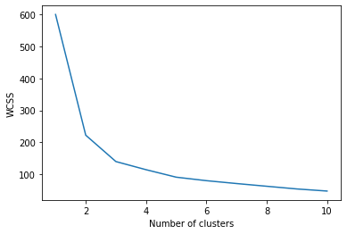

```python
# Determine the number of clusters
wcss = []
for i in range(1, 11):
    kmeans = KMeans(n_clusters=i, random_state=0)
    kmeans.fit(X_std)
    wcss.append(kmeans.inertia_)
plt.plot(range(1, 11), wcss)
plt.xlabel('Number of clusters')
plt.ylabel('WCSS')
plt.show()
```

Once the number of clusters is determined, the k-means algorithm can be run on the standardized data. The algorithm assigns each data point to the nearest cluster center based on the Euclidean distance. Then, it computes the mean of the data points in each cluster and updates the cluster center. The algorithm repeats this process until the cluster centers converge.

```python
# Run the k-means algorithm
kmeans = KMeans(n_clusters=3, random_state=0)
y_kmeans = kmeans.fit_predict(X_std)
```

After running the k-means algorithm, it's important to evaluate the results. One way to do this is to plot the data points with different colors representing the assigned clusters. This allows you to visually inspect the clusters and see if they make sense.

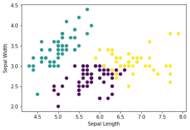

```python
# Plot the results
plt.scatter(X[:, 0], X[:, 1], c=y_kmeans)
plt.xlabel('Sepal Length')
plt.ylabel('Sepal Width')
plt.show()
```

Another way to evaluate the results is to calculate the silhouette score, which measures the similarity of data points within a cluster compared to data points in other clusters. Typically, a silhouette score of 0.5 or higher is considered to indicate a reasonably good clustering. However, it is important to note that an ideal score is 1, and a score less than 0 indicates that the clustering is poor and the sample is probably assigned to the wrong cluster. YellowBrick is a machine learning visualization library that can be used to draw silhouette plots and perform comparative analysis.

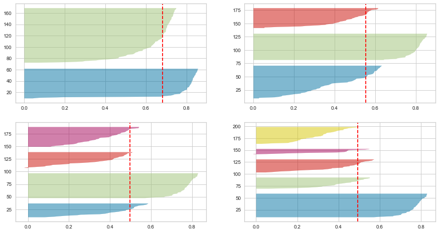

```python
from yellowbrick.cluster import SilhouetteVisualizer

fig, ax = plt.subplots(2, 2, figsize=(15,8))
for i in [2, 3, 4, 5]:
    '''
    Create KMeans instance for different number of clusters
    '''
    km = KMeans(n_clusters=i, init='k-means++', n_init=10, max_iter=100, random_state=0)
    q, mod = divmod(i, 2)
    '''
    Create SilhouetteVisualizer instance with KMeans instance
    Fit the visualizer
    '''
    visualizer = SilhouetteVisualizer(km, colors='yellowbrick', ax=ax[q-1][mod])
    visualizer.fit(X)
```

We can see that clusters of 4 and 5 are suboptimal since:

- There are clusters with below average silhouette scores
- Wide variation in thickness of silhouette plots

Between clusters of 2 and 3, k = 3 appears to be most optimal as the thickness of its silhouette plots appear more uniform.